# Neural Networks in Finance - Task 1

Group D

2025-06-19

## Exercise 1: Markov Chains in Finance

Markov chains represent stochastic processes where future states depend only on the current state, not on the sequence of events that preceded it. In finance, this concept is particularly useful for modeling credit rating transitions, where a company’s future credit rating depends primarily on its current rating rather than its historical rating path.

## Exercise 2: Market Data Preparation

```r
#' Retrieve and process SPY returns data
#'
#' @param start_date Character string representing start date for data retrieval
#' @return Tibble containing date, price, and return percentage columns
get_spy_returns <- function(start_date = "2015-01-01") {
  # Fetch raw market data
  raw_data <- quantmod::getSymbols(
    "SPY",
    src = "yahoo",
    from = start_date,
    auto.assign = FALSE,
    warnings = FALSE
  )

  # Transform to clean data frame structure
  prices_df <- data.frame(
    date = index(Ad(raw_data)),
    price = as.numeric(Ad(raw_data))
  ) %>%
    as_tibble()

  # Calculate percentage returns
  prices_df %>%
    dplyr::mutate(
      return_percentage = (price / lag(price, 1) - 1) * 100
    ) %>%
    dplyr::filter(!is.na(return_percentage)) %>%
    dplyr::select(date, price, return_percentage)
}

# Load SPY data
spy_returns <- get_spy_returns("2015-01-01")
cat("SPY returns loaded:", nrow(spy_returns), "observations\n")
```

```
#> SPY returns loaded: 2630 observations
```

### SPY Price Visualization

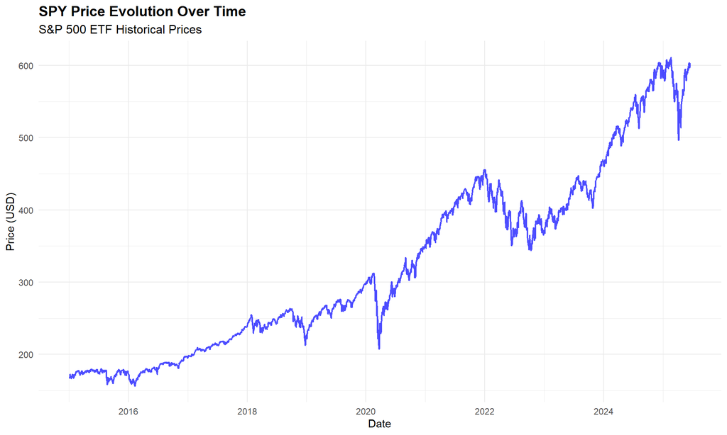

```r
price_plot <- ggplot2::ggplot(spy_returns, ggplot2::aes(x = date, y = price)) +
  ggplot2::geom_line(color = "blue", alpha = 0.7, size = 0.8) +
  ggplot2::labs(
    title = "SPY Price Evolution Over Time",
    subtitle = "S&P 500 ETF Historical Prices",
    x = "Date",
    y = "Price (USD)"
  ) +
  ggplot2::theme_minimal() +
  ggplot2::theme(
    plot.title = element_text(size = 14, face = "bold"),
    plot.subtitle = element_text(size = 12)
  )

print(price_plot)
```

## Exercise 3: State Vector Implementation

State vectors capture the recent history of market returns that will be used as input to our neural network. The state represents the “memory” of the system at any given time.

```r
#' Create state vector from return data
#'
#' @param return_data Tibble containing return data with return_percentage column
#' @param time_index Integer representing the time index for state creation
#' @param window_size Integer representing the lookback window size
#' @return Numeric vector representing the state
make_state <- function(return_data, time_index, window_size = 10) {
  if (time_index < window_size) {
    stop("Time index must be greater than or equal to window size")
  }

  return_data$return_percentage[(time_index - window_size + 1):time_index]
}

# Demonstrate state vector creation
demo_state_vector <- make_state(spy_returns, time_index = 15)
cat("State vector at t=15:", paste(round(demo_state_vector, 3), collapse = ", "), "\n")
```

```
#> State vector at t=15: -0.783, -0.281, -0.604, -0.916, 1.311, 0.213, 0.505, 1.487, -0.548, 0.234
```

**State Vector Interpretation:** - Each state vector contains the last 10 daily returns - This captures short-term market momentum and volatility patterns - The neural network will learn to map these patterns to optimal actions

## Exercise 4: Q-Network Architecture Design

The Q-network approximates the Q-function in reinforcement learning, estimating the expected future reward for each possible action given the current state.

```r
# Define action space and network parameters
ACTIONS <- c("Long", "Flat")
INPUT_NODES <- 10    # State vector dimension
OUTPUT_NODES <- length(ACTIONS)  # Number of possible actions
HIDDEN_UNITS <- 32   # Hidden layer size

# Create Keras sequential model
q_network_model <- keras_model_sequential() %>%
  layer_dense(
    units = HIDDEN_UNITS,
    activation = "relu",
    input_shape = c(INPUT_NODES),
    name = "hidden_layer"
  ) %>%
  layer_dense(
    units = OUTPUT_NODES,
    activation = "linear",
    name = "q_values_output"
  )

# Display model architecture
summary(q_network_model)
```

```
#> Model: "sequential"
#> ________________________________________________________________________________
#>  Layer (type)                       Output Shape                    Param #
#> ================================================================================
#>  hidden_layer (Dense)               (None, 32)                      352
#>  q_values_output (Dense)            (None, 2)                       66
#> ================================================================================
#> Total params: 418 (1.63 KB)
#> Trainable params: 418 (1.63 KB)
#> Non-trainable params: 0 (0.00 Byte)
#> ________________________________________________________________________________
```

```r
cat("Q-Network model successfully created\n")
```

```
#> Q-Network model successfully created
```

**Architecture Rationale:** - **Input Layer**: 10 nodes (recent return history) - **Hidden Layer**: 32 nodes with ReLU activation (non-linear feature extraction) - **Output Layer**: 2 nodes with linear activation (Q-values for Long/Flat actions)

**Output Interpretation:** - First output: Q-value for “Long” action (expected reward for buying) - Second output: Q-value for “Flat” action (expected reward for holding cash)

## Exercise 5: Artificial Target Generation

```r
#' Generate training targets for Q-network
#'
#' @param num_samples Integer number of training samples to generate
#' @param returns_data Tibble containing return data
#' @return List containing states matrix and targets matrix
generate_training_targets <- function(num_samples = 256, returns_data = spy_returns) {
  # Sample random time indices (avoiding boundary conditions)
  sample_idx <- sample(
    10:(length(returns_data$return_percentage) - 1),
    num_samples
  )

  # Create state matrix (each row is a state vector)
  states_mat <- t(sapply(sample_idx, function(i) make_state(returns_data, i)))

  # Extract current and next period returns
  return_t <- returns_data$return_percentage[sample_idx]
  return_t_plus_1 <- returns_data$return_percentage[sample_idx + 1]

  # Generate targets: reward for "Long" action based on trend continuation
  y_long <- as.numeric(return_t_plus_1 > return_t)

  list(
    states = states_mat,
    targets = cbind(y_long = y_long, y_flat = 1 - y_long)
  )
}

# Generate training data
training_data <- generate_training_targets(256)
cat("Training targets generated:\n")
```

```
#> Training targets generated:
```

```r
cat("Long signals:", sum(training_data$targets[, "y_long"]), "\n")
```

```
#> Long signals: 113
```

```r
cat("Flat signals:", sum(training_data$targets[, "y_flat"]), "\n")
```

```
#> Flat signals: 143
```

**Agent Strategy Interpretation:** This target generation creates a **trend-following agent** that: - Goes long when expecting returns to continue in the same direction - Stays flat when trend reversal is expected - Uses simple momentum-based logic for target generation

## Exercise 6: Model Training and Compilation

```r
#' Train the Q-network model
#'
#' @param states_data Matrix of state vectors
#' @param targets_data Matrix of target Q-values
#' @param epochs Integer number of training epochs
#' @param lr Numeric learning rate for optimization
#' @param model_to_train Keras model object to train
#' @return List containing trained model, loss history, and final MSE
train_q_network <- function(states_data, targets_data, epochs = 20, lr = 0.001, model_to_train = q_network_model) {
  # Configure optimizer
  optimizer <- optimizer_adam(learning_rate = lr)

  # Compile model
  model_to_train %>% compile(
    optimizer = optimizer,
    loss = "mse",
    metrics = c("mae")
  )

  # Train model
  history <- model_to_train %>% fit(
    x = states_data,
    y = targets_data,
    epochs = epochs,
    batch_size = 32,
    validation_split = 0.2,
    verbose = 1
  )

  list(
    model = model_to_train,
    loss_history = history$metrics$loss,
    final_mse = tail(history$metrics$loss, 1)
  )
}

#' Plot training loss curve
#'
#' @param loss_history Numeric vector of loss values by epoch
#' @return ggplot object
plot_loss_curve <- function(loss_history) {
  loss_df <- data.frame(
    epoch = 1:length(loss_history),
    loss = loss_history
  )

  ggplot2::ggplot(loss_df, ggplot2::aes(x = epoch, y = loss)) +
    ggplot2::geom_line(color = "red", size = 1) +
    ggplot2::geom_point(color = "darkred", size = 2) +
    ggplot2::labs(
      title = "Q-Network Training Loss",
      subtitle = "Mean Squared Error by Epoch",
      x = "Epoch",
      y = "MSE Loss"
    ) +
    ggplot2::theme_minimal() +
    ggplot2::theme(
      plot.title = element_text(size = 14, face = "bold"),
      plot.subtitle = element_text(size = 12)
    )
}

# Train the model
training_results <- train_q_network(training_data$states, training_data$targets)
cat("Final training MSE:", round(training_results$final_mse, 5), "\n")
```

```
#> Final training MSE: 0.277
```

### Training Loss Visualization

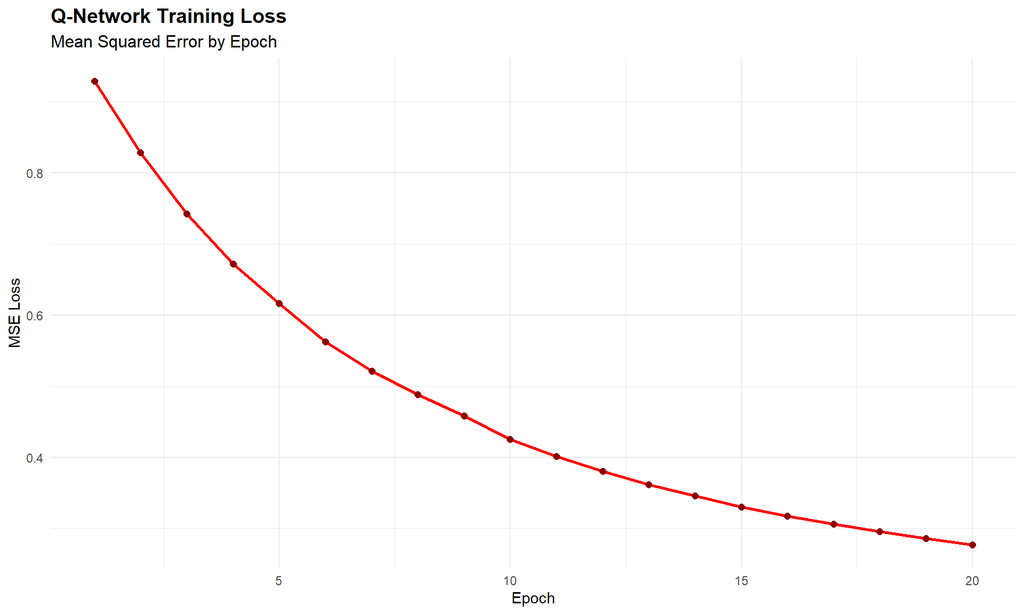

```r
print(plot_loss_curve(training_results$loss_history))
```

## Exercise 7: Q-Function Inspection and Analysis

```r
#' Predict Q-values for a given state
#'
#' @param state_v Numeric vector representing the state
#' @param model Trained Keras model
#' @return Named numeric vector of Q-values for each action
predict_q_values <- function(state_v, model) {
  # Reshape input for Keras prediction
  input_for_predict <- array_reshape(state_v, c(1, INPUT_NODES))

  # Get Q-value predictions
  q_vals <- model %>% predict(input_for_predict, verbose = 0)

  # Return named vector
  setNames(as.vector(q_vals), ACTIONS)
}

#' Inspect Q-function performance on current market state
#'
#' @param model Trained Keras model
#' @param returns_data Tibble containing return data
#' @return Named numeric vector of current Q-values
inspect_q_function <- function(model, returns_data = spy_returns) {
  # Get most recent state
  current_state <- make_state(returns_data, nrow(returns_data))

  # Predict Q-values
  q_vals_named <- predict_q_values(current_state, model)

  # Display results
  cat("=== Q-Function Analysis ===\n")
  cat("Current state (last 10 returns):", paste(round(current_state, 3), collapse = ", "), "\n")
  cat("Q-values:\n")
  cat("  Long:", round(q_vals_named["Long"], 4), "\n")
  cat("  Flat:", round(q_vals_named["Flat"], 4), "\n")

  # Determine optimal action
  optimal_action <- ifelse(
    q_vals_named["Long"] > q_vals_named["Flat"],
    "GO LONG",
    "STAY FLAT"
  )
  cat("Recommended Action:", optimal_action, "\n")

  return(q_vals_named)
}

# Perform Q-function inspection
current_q_values <- inspect_q_function(training_results$model)
```

```
#> === Q-Function Analysis ===
#> Current state (last 10 returns): -0.483, 1.027, 0.09, 0.567, -0.285, 0.397, -1.118, 0.951, -0.855, -0.015
#> Q-values:
#>   Long: 0.2701
#>   Flat: 0.6483
#> Recommended Action: STAY FLAT
```